# Risk Factor Analysis

## Outcome Variable

**Outcome Variable:** wast_rec90d

## Predictor Variables

**Intervention Variable:** brthmon

**Adjustment Set:**

unadjusted

## Stratifying Variables

The analysis was stratified on these variable(s):

- agecat
- studyid
- country

## Data Summary

| agecat | studyid | country | brthmon | wast_rec90d | n_cell | n |
| --- | --- | --- | --- | --- | --- | --- |
| 0-24 months | ki0047075b-MAL-ED | BANGLADESH | 1 | 0 | 3 | 124 |
| 0-24 months | ki0047075b-MAL-ED | BANGLADESH | 1 | 1 | 5 | 124 |
| 0-24 months | ki0047075b-MAL-ED | BANGLADESH | 2 | 0 | 5 | 124 |
| 0-24 months | ki0047075b-MAL-ED | BANGLADESH | 2 | 1 | 9 | 124 |
| 0-24 months | ki0047075b-MAL-ED | BANGLADESH | 3 | 0 | 8 | 124 |
| 0-24 months | ki0047075b-MAL-ED | BANGLADESH | 3 | 1 | 15 | 124 |
| 0-24 months | ki0047075b-MAL-ED | BANGLADESH | 4 | 0 | 4 | 124 |
| 0-24 months | ki0047075b-MAL-ED | BANGLADESH | 4 | 1 | 5 | 124 |
| 0-24 months | ki0047075b-MAL-ED | BANGLADESH | 5 | 0 | 6 | 124 |
| 0-24 months | ki0047075b-MAL-ED | BANGLADESH | 5 | 1 | 6 | 124 |
| 0-24 months | ki0047075b-MAL-ED | BANGLADESH | 6 | 0 | 1 | 124 |
| 0-24 months | ki0047075b-MAL-ED | BANGLADESH | 6 | 1 | 1 | 124 |
| 0-24 months | ki0047075b-MAL-ED | BANGLADESH | 7 | 0 | 4 | 124 |
| 0-24 months | ki0047075b-MAL-ED | BANGLADESH | 7 | 1 | 9 | 124 |
| 0-24 months | ki0047075b-MAL-ED | BANGLADESH | 8 | 0 | 1 | 124 |
| 0-24 months | ki0047075b-MAL-ED | BANGLADESH | 8 | 1 | 3 | 124 |
| 0-24 months | ki0047075b-MAL-ED | BANGLADESH | 9 | 0 | 5 | 124 |
| 0-24 months | ki0047075b-MAL-ED | BANGLADESH | 9 | 1 | 16 | 124 |
| 0-24 months | ki0047075b-MAL-ED | BANGLADESH | 10 | 0 | 3 | 124 |
| 0-24 months | ki0047075b-MAL-ED | BANGLADESH | 10 | 1 | 3 | 124 |
| 0-24 months | ki0047075b-MAL-ED | BANGLADESH | 11 | 0 | 2 | 124 |
| 0-24 months | ki0047075b-MAL-ED | BANGLADESH | 11 | 1 | 2 | 124 |
| 0-24 months | ki0047075b-MAL-ED | BANGLADESH | 12 | 0 | 3 | 124 |
| 0-24 months | ki0047075b-MAL-ED | BANGLADESH | 12 | 1 | 5 | 124 |
| 0-24 months | ki0047075b-MAL-ED | BRAZIL | 1 | 0 | 0 | 23 |
| 0-24 months | ki0047075b-MAL-ED | BRAZIL | 1 | 1 | 2 | 23 |
| 0-24 months | ki0047075b-MAL-ED | BRAZIL | 2 | 0 | 1 | 23 |
| 0-24 months | ki0047075b-MAL-ED | BRAZIL | 2 | 1 | 2 | 23 |
| 0-24 months | ki0047075b-MAL-ED | BRAZIL | 3 | 0 | 1 | 23 |
| 0-24 months | ki0047075b-MAL-ED | BRAZIL | 3 | 1 | 0 | 23 |

[output cut: 2034 more lines]

The following strata were considered:

- agecat: 0-24 months, studyid: ki0047075b-MAL-ED, country: BANGLADESH
- agecat: 0-24 months, studyid: ki0047075b-MAL-ED, country: BRAZIL
- agecat: 0-24 months, studyid: ki0047075b-MAL-ED, country: INDIA
- agecat: 0-24 months, studyid: ki0047075b-MAL-ED, country: NEPAL
- agecat: 0-24 months, studyid: ki0047075b-MAL-ED, country: PERU
- agecat: 0-24 months, studyid: ki0047075b-MAL-ED, country: SOUTH AFRICA
- agecat: 0-24 months, studyid: ki0047075b-MAL-ED, country: TANZANIA, UNITED REPUBLIC OF
- agecat: 0-24 months, studyid: ki1000108-CMC-V-BCS-2002, country: INDIA
- agecat: 0-24 months, studyid: ki1000108-IRC, country: INDIA
- agecat: 0-24 months, studyid: ki1000109-EE, country: PAKISTAN
- agecat: 0-24 months, studyid: ki1000109-ResPak, country: PAKISTAN
- agecat: 0-24 months, studyid: ki1000304b-SAS-CompFeed, country: INDIA
- agecat: 0-24 months, studyid: ki1000304b-SAS-FoodSuppl, country: INDIA
- agecat: 0-24 months, studyid: ki1017093-NIH-Birth, country: BANGLADESH
- agecat: 0-24 months, studyid: ki1066203-TanzaniaChild2, country: TANZANIA, UNITED REPUBLIC OF
- agecat: 0-24 months, studyid: ki1101329-Keneba, country: GAMBIA
- agecat: 0-24 months, studyid: ki1112895-Guatemala BSC, country: GUATEMALA
- agecat: 0-24 months, studyid: ki1112895-iLiNS-Zinc, country: BURKINA FASO
- agecat: 0-24 months, studyid: ki1113344-GMS-Nepal, country: NEPAL
- agecat: 0-24 months, studyid: ki1114097-CMIN, country: BANGLADESH
- agecat: 0-24 months, studyid: ki1114097-CMIN, country: BRAZIL
- agecat: 0-24 months, studyid: ki1114097-CMIN, country: GUINEA-BISSAU
- agecat: 0-24 months, studyid: ki1114097-CMIN, country: PERU
- agecat: 0-24 months, studyid: ki1114097-CONTENT, country: PERU
- agecat: 0-24 months, studyid: ki1119695-PROBIT, country: BELARUS
- agecat: 0-24 months, studyid: ki1126311-ZVITAMBO, country: ZIMBABWE
- agecat: 0-24 months, studyid: ki1148112-LCNI-5, country: MALAWI
- agecat: 0-24 months, studyid: kiGH5241-JiVitA-3, country: BANGLADESH
- agecat: 0-24 months, studyid: kiGH5241-JiVitA-4, country: BANGLADESH
- agecat: 0-6 months, studyid: ki0047075b-MAL-ED, country: BANGLADESH
- agecat: 0-6 months, studyid: ki0047075b-MAL-ED, country: BRAZIL
- agecat: 0-6 months, studyid: ki0047075b-MAL-ED, country: INDIA
- agecat: 0-6 months, studyid: ki0047075b-MAL-ED, country: NEPAL
- agecat: 0-6 months, studyid: ki0047075b-MAL-ED, country: PERU
- agecat: 0-6 months, studyid: ki0047075b-MAL-ED, country: SOUTH AFRICA
- agecat: 0-6 months, studyid: ki0047075b-MAL-ED, country: TANZANIA, UNITED REPUBLIC OF
- agecat: 0-6 months, studyid: ki1000108-CMC-V-BCS-2002, country: INDIA
- agecat: 0-6 months, studyid: ki1000108-IRC, country: INDIA
- agecat: 0-6 months, studyid: ki1000109-EE, country: PAKISTAN
- agecat: 0-6 months, studyid: ki1000109-ResPak, country: PAKISTAN
- agecat: 0-6 months, studyid: ki1000304b-SAS-CompFeed, country: INDIA
- agecat: 0-6 months, studyid: ki1000304b-SAS-FoodSuppl, country: INDIA
- agecat: 0-6 months, studyid: ki1017093-NIH-Birth, country: BANGLADESH
- agecat: 0-6 months, studyid: ki1066203-TanzaniaChild2, country: TANZANIA, UNITED REPUBLIC OF
- agecat: 0-6 months, studyid: ki1101329-Keneba, country: GAMBIA
- agecat: 0-6 months, studyid: ki1112895-Guatemala BSC, country: GUATEMALA
- agecat: 0-6 months, studyid: ki1113344-GMS-Nepal, country: NEPAL
- agecat: 0-6 months, studyid: ki1114097-CMIN, country: BANGLADESH
- agecat: 0-6 months, studyid: ki1114097-CMIN, country: BRAZIL
- agecat: 0-6 months, studyid: ki1114097-CMIN, country: GUINEA-BISSAU
- agecat: 0-6 months, studyid: ki1114097-CMIN, country: PERU
- agecat: 0-6 months, studyid: ki1114097-CONTENT, country: PERU
- agecat: 0-6 months, studyid: ki1119695-PROBIT, country: BELARUS
- agecat: 0-6 months, studyid: ki1126311-ZVITAMBO, country: ZIMBABWE
- agecat: 0-6 months, studyid: ki1148112-LCNI-5, country: MALAWI
- agecat: 0-6 months, studyid: kiGH5241-JiVitA-3, country: BANGLADESH
- agecat: 0-6 months, studyid: kiGH5241-JiVitA-4, country: BANGLADESH
- agecat: 6-24 months, studyid: ki0047075b-MAL-ED, country: BANGLADESH
- agecat: 6-24 months, studyid: ki0047075b-MAL-ED, country: BRAZIL
- agecat: 6-24 months, studyid: ki0047075b-MAL-ED, country: INDIA
- agecat: 6-24 months, studyid: ki0047075b-MAL-ED, country: NEPAL
- agecat: 6-24 months, studyid: ki0047075b-MAL-ED, country: PERU
- agecat: 6-24 months, studyid: ki0047075b-MAL-ED, country: SOUTH AFRICA
- agecat: 6-24 months, studyid: ki0047075b-MAL-ED, country: TANZANIA, UNITED REPUBLIC OF
- agecat: 6-24 months, studyid: ki1000108-CMC-V-BCS-2002, country: INDIA
- agecat: 6-24 months, studyid: ki1000108-IRC, country: INDIA
- agecat: 6-24 months, studyid: ki1000109-EE, country: PAKISTAN
- agecat: 6-24 months, studyid: ki1000109-ResPak, country: PAKISTAN
- agecat: 6-24 months, studyid: ki1000304b-SAS-CompFeed, country: INDIA
- agecat: 6-24 months, studyid: ki1000304b-SAS-FoodSuppl, country: INDIA
- agecat: 6-24 months, studyid: ki1017093-NIH-Birth, country: BANGLADESH
- agecat: 6-24 months, studyid: ki1066203-TanzaniaChild2, country: TANZANIA, UNITED REPUBLIC OF
- agecat: 6-24 months, studyid: ki1101329-Keneba, country: GAMBIA
- agecat: 6-24 months, studyid: ki1112895-Guatemala BSC, country: GUATEMALA
- agecat: 6-24 months, studyid: ki1112895-iLiNS-Zinc, country: BURKINA FASO
- agecat: 6-24 months, studyid: ki1113344-GMS-Nepal, country: NEPAL
- agecat: 6-24 months, studyid: ki1114097-CMIN, country: BANGLADESH
- agecat: 6-24 months, studyid: ki1114097-CMIN, country: BRAZIL
- agecat: 6-24 months, studyid: ki1114097-CMIN, country: GUINEA-BISSAU
- agecat: 6-24 months, studyid: ki1114097-CMIN, country: PERU
- agecat: 6-24 months, studyid: ki1114097-CONTENT, country: PERU
- agecat: 6-24 months, studyid: ki1119695-PROBIT, country: BELARUS
- agecat: 6-24 months, studyid: ki1126311-ZVITAMBO, country: ZIMBABWE
- agecat: 6-24 months, studyid: ki1148112-LCNI-5, country: MALAWI
- agecat: 6-24 months, studyid: kiGH5241-JiVitA-3, country: BANGLADESH
- agecat: 6-24 months, studyid: kiGH5241-JiVitA-4, country: BANGLADESH

### Dropped Strata

Some strata were dropped due to rare outcomes:

- agecat: 0-24 months, studyid: ki0047075b-MAL-ED, country: BANGLADESH
- agecat: 0-24 months, studyid: ki0047075b-MAL-ED, country: BRAZIL
- agecat: 0-24 months, studyid: ki0047075b-MAL-ED, country: INDIA
- agecat: 0-24 months, studyid: ki0047075b-MAL-ED, country: NEPAL
- agecat: 0-24 months, studyid: ki0047075b-MAL-ED, country: PERU
- agecat: 0-24 months, studyid: ki0047075b-MAL-ED, country: SOUTH AFRICA
- agecat: 0-24 months, studyid: ki0047075b-MAL-ED, country: TANZANIA, UNITED REPUBLIC OF
- agecat: 0-24 months, studyid: ki1000108-CMC-V-BCS-2002, country: INDIA
- agecat: 0-24 months, studyid: ki1000109-EE, country: PAKISTAN
- agecat: 0-24 months, studyid: ki1000109-ResPak, country: PAKISTAN
- agecat: 0-24 months, studyid: ki1000304b-SAS-FoodSuppl, country: INDIA
- agecat: 0-24 months, studyid: ki1112895-Guatemala BSC, country: GUATEMALA
- agecat: 0-24 months, studyid: ki1112895-iLiNS-Zinc, country: BURKINA FASO
- agecat: 0-24 months, studyid: ki1113344-GMS-Nepal, country: NEPAL
- agecat: 0-24 months, studyid: ki1114097-CMIN, country: BANGLADESH
- agecat: 0-24 months, studyid: ki1114097-CMIN, country: BRAZIL
- agecat: 0-24 months, studyid: ki1114097-CMIN, country: GUINEA-BISSAU
- agecat: 0-24 months, studyid: ki1114097-CMIN, country: PERU
- agecat: 0-24 months, studyid: ki1114097-CONTENT, country: PERU
- agecat: 0-24 months, studyid: ki1148112-LCNI-5, country: MALAWI
- agecat: 0-24 months, studyid: kiGH5241-JiVitA-4, country: BANGLADESH
- agecat: 0-6 months, studyid: ki0047075b-MAL-ED, country: BANGLADESH
- agecat: 0-6 months, studyid: ki0047075b-MAL-ED, country: BRAZIL
- agecat: 0-6 months, studyid: ki0047075b-MAL-ED, country: INDIA
- agecat: 0-6 months, studyid: ki0047075b-MAL-ED, country: NEPAL
- agecat: 0-6 months, studyid: ki0047075b-MAL-ED, country: PERU
- agecat: 0-6 months, studyid: ki0047075b-MAL-ED, country: SOUTH AFRICA
- agecat: 0-6 months, studyid: ki0047075b-MAL-ED, country: TANZANIA, UNITED REPUBLIC OF
- agecat: 0-6 months, studyid: ki1000108-CMC-V-BCS-2002, country: INDIA
- agecat: 0-6 months, studyid: ki1000108-IRC, country: INDIA
- agecat: 0-6 months, studyid: ki1000109-EE, country: PAKISTAN
- agecat: 0-6 months, studyid: ki1000109-ResPak, country: PAKISTAN
- agecat: 0-6 months, studyid: ki1000304b-SAS-FoodSuppl, country: INDIA
- agecat: 0-6 months, studyid: ki1017093-NIH-Birth, country: BANGLADESH
- agecat: 0-6 months, studyid: ki1066203-TanzaniaChild2, country: TANZANIA, UNITED REPUBLIC OF
- agecat: 0-6 months, studyid: ki1112895-Guatemala BSC, country: GUATEMALA
- agecat: 0-6 months, studyid: ki1113344-GMS-Nepal, country: NEPAL
- agecat: 0-6 months, studyid: ki1114097-CMIN, country: BANGLADESH
- agecat: 0-6 months, studyid: ki1114097-CMIN, country: BRAZIL
- agecat: 0-6 months, studyid: ki1114097-CMIN, country: GUINEA-BISSAU
- agecat: 0-6 months, studyid: ki1114097-CMIN, country: PERU
- agecat: 0-6 months, studyid: ki1114097-CONTENT, country: PERU
- agecat: 0-6 months, studyid: ki1148112-LCNI-5, country: MALAWI
- agecat: 0-6 months, studyid: kiGH5241-JiVitA-4, country: BANGLADESH
- agecat: 6-24 months, studyid: ki0047075b-MAL-ED, country: BANGLADESH
- agecat: 6-24 months, studyid: ki0047075b-MAL-ED, country: BRAZIL
- agecat: 6-24 months, studyid: ki0047075b-MAL-ED, country: INDIA
- agecat: 6-24 months, studyid: ki0047075b-MAL-ED, country: NEPAL
- agecat: 6-24 months, studyid: ki0047075b-MAL-ED, country: PERU
- agecat: 6-24 months, studyid: ki0047075b-MAL-ED, country: SOUTH AFRICA
- agecat: 6-24 months, studyid: ki0047075b-MAL-ED, country: TANZANIA, UNITED REPUBLIC OF
- agecat: 6-24 months, studyid: ki1000108-CMC-V-BCS-2002, country: INDIA
- agecat: 6-24 months, studyid: ki1000108-IRC, country: INDIA
- agecat: 6-24 months, studyid: ki1000109-EE, country: PAKISTAN
- agecat: 6-24 months, studyid: ki1000109-ResPak, country: PAKISTAN
- agecat: 6-24 months, studyid: ki1000304b-SAS-CompFeed, country: INDIA
- agecat: 6-24 months, studyid: ki1000304b-SAS-FoodSuppl, country: INDIA
- agecat: 6-24 months, studyid: ki1017093-NIH-Birth, country: BANGLADESH
- agecat: 6-24 months, studyid: ki1112895-Guatemala BSC, country: GUATEMALA
- agecat: 6-24 months, studyid: ki1112895-iLiNS-Zinc, country: BURKINA FASO
- agecat: 6-24 months, studyid: ki1113344-GMS-Nepal, country: NEPAL
- agecat: 6-24 months, studyid: ki1114097-CMIN, country: BANGLADESH
- agecat: 6-24 months, studyid: ki1114097-CMIN, country: BRAZIL
- agecat: 6-24 months, studyid: ki1114097-CMIN, country: GUINEA-BISSAU
- agecat: 6-24 months, studyid: ki1114097-CMIN, country: PERU
- agecat: 6-24 months, studyid: ki1114097-CONTENT, country: PERU
- agecat: 6-24 months, studyid: ki1119695-PROBIT, country: BELARUS
- agecat: 6-24 months, studyid: ki1126311-ZVITAMBO, country: ZIMBABWE
- agecat: 6-24 months, studyid: ki1148112-LCNI-5, country: MALAWI
- agecat: 6-24 months, studyid: kiGH5241-JiVitA-3, country: BANGLADESH
- agecat: 6-24 months, studyid: kiGH5241-JiVitA-4, country: BANGLADESH

## Methods Detail

We’re interested in the causal parameters $E[Y_a]$ for all values of $a \in \mathcal{A}$. These parameters represent the mean outcome if, possibly contrary to fact, we intervened to set all units to have $A=a$. Under the randomization and positivity assumptions, these are identified by the statistical parameters $\psi_a=E_W[E_{Y|A,W}(Y|A=a,W)]$. In addition, we’re interested in the mean of $Y$, $E[Y]$ under no intervention (the observed mean). We will estimate these parameters by using SuperLearner to fit the relevant likelihood factors – $E_{Y|A,W}(Y|A=a,W)$ and $p(A=a|W)$, and then updating our likelihood fit using a joint TMLE.

For unadjusted analyses ($W=\{\}$), initial likelihoods were estimated using Lrnr_glm to estimate the simple $E(Y|A)$ and Lrnr_mean to estimate $p(A)$. For adjusted analyses, a small library containing Lrnr_glmnet, Lrnr_xgboost, and Lrnr_mean was used.

Having estimated these parameters, we will then use the delta method to estimate relative risks and attributable risks relative to a prespecified baseline level of $A$.

# Results Detail

## Results Plots

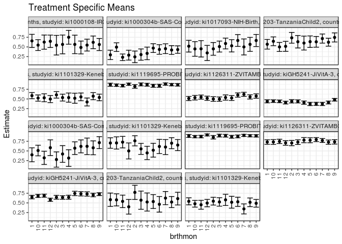

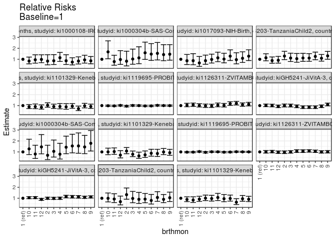

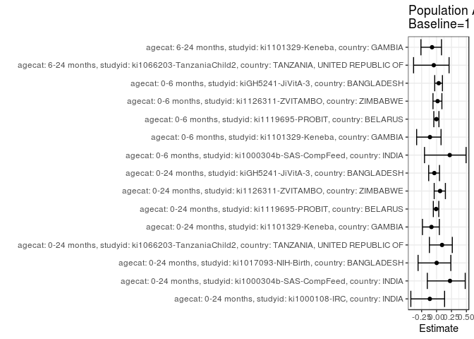

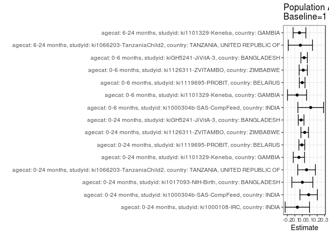

## Results Table

### Parameter: TSM

| agecat | studyid | country | intervention_level | baseline_level | estimate | ci_lower | ci_upper |
| --- | --- | --- | --- | --- | --- | --- | --- |
| 0-24 months | ki1000108-IRC | INDIA | 1 | NA | 0.6562500 | 0.4858806 | 0.8266194 |
| 0-24 months | ki1000108-IRC | INDIA | 2 | NA | 0.5454545 | 0.2915765 | 0.7993325 |
| 0-24 months | ki1000108-IRC | INDIA | 3 | NA | 0.5652174 | 0.3222657 | 0.8081691 |
| 0-24 months | ki1000108-IRC | INDIA | 4 | NA | 0.7500000 | 0.5708445 | 0.9291555 |
| 0-24 months | ki1000108-IRC | INDIA | 5 | NA | 0.5652174 | 0.3263159 | 0.8041189 |
| 0-24 months | ki1000108-IRC | INDIA | 6 | NA | 0.4864865 | 0.3200836 | 0.6528893 |
| 0-24 months | ki1000108-IRC | INDIA | 7 | NA | 0.5476190 | 0.3946365 | 0.7006016 |
| 0-24 months | ki1000108-IRC | INDIA | 8 | NA | 0.6190476 | 0.4554007 | 0.7826945 |
| 0-24 months | ki1000108-IRC | INDIA | 9 | NA | 0.5625000 | 0.4064115 | 0.7185885 |
| 0-24 months | ki1000108-IRC | INDIA | 10 | NA | 0.5476190 | 0.4075303 | 0.6877078 |
| 0-24 months | ki1000108-IRC | INDIA | 11 | NA | 0.6250000 | 0.4423429 | 0.8076571 |
| 0-24 months | ki1000108-IRC | INDIA | 12 | NA | 0.6458333 | 0.4853215 | 0.8063452 |
| 0-24 months | ki1000304b-SAS-CompFeed | INDIA | 1 | NA | 0.2950820 | 0.1734112 | 0.4167527 |
| 0-24 months | ki1000304b-SAS-CompFeed | INDIA | 2 | NA | 0.2432432 | 0.0925306 | 0.3939559 |
| 0-24 months | ki1000304b-SAS-CompFeed | INDIA | 3 | NA | 0.3023256 | 0.1572317 | 0.4474195 |
| 0-24 months | ki1000304b-SAS-CompFeed | INDIA | 4 | NA | 0.3333333 | 0.1703412 | 0.4963255 |
| 0-24 months | ki1000304b-SAS-CompFeed | INDIA | 5 | NA | 0.4696970 | 0.3561155 | 0.5832784 |
| 0-24 months | ki1000304b-SAS-CompFeed | INDIA | 6 | NA | 0.4347826 | 0.3111314 | 0.5584338 |
| 0-24 months | ki1000304b-SAS-CompFeed | INDIA | 7 | NA | 0.4545455 | 0.3277480 | 0.5813430 |
| 0-24 months | ki1000304b-SAS-CompFeed | INDIA | 8 | NA | 0.4204545 | 0.3066579 | 0.5342512 |
| 0-24 months | ki1000304b-SAS-CompFeed | INDIA | 9 | NA | 0.4313725 | 0.3346542 | 0.5280909 |
| 0-24 months | ki1000304b-SAS-CompFeed | INDIA | 10 | NA | 0.4947368 | 0.3828076 | 0.6066661 |
| 0-24 months | ki1000304b-SAS-CompFeed | INDIA | 11 | NA | 0.2325581 | 0.1480315 | 0.3170847 |
| 0-24 months | ki1000304b-SAS-CompFeed | INDIA | 12 | NA | 0.2881356 | 0.1606482 | 0.4156230 |
| 0-24 months | ki1017093-NIH-Birth | BANGLADESH | 1 | NA | 0.5192308 | 0.3677287 | 0.6707328 |
| 0-24 months | ki1017093-NIH-Birth | BANGLADESH | 2 | NA | 0.4500000 | 0.2860503 | 0.6139497 |
| 0-24 months | ki1017093-NIH-Birth | BANGLADESH | 3 | NA | 0.5102041 | 0.3682818 | 0.6521263 |
| 0-24 months | ki1017093-NIH-Birth | BANGLADESH | 4 | NA | 0.5882353 | 0.4490052 | 0.7274654 |
| 0-24 months | ki1017093-NIH-Birth | BANGLADESH | 5 | NA | 0.5294118 | 0.3709352 | 0.6878884 |
| 0-24 months | ki1017093-NIH-Birth | BANGLADESH | 6 | NA | 0.6666667 | 0.5144110 | 0.8189223 |

[output cut: 150 more lines]

### Parameter: E(Y)

| agecat | studyid | country | intervention_level | baseline_level | estimate | ci_lower | ci_upper |
| --- | --- | --- | --- | --- | --- | --- | --- |
| 0-24 months | ki1000108-IRC | INDIA | NA | NA | 0.5898734 | 0.5376978 | 0.6420491 |
| 0-24 months | ki1000304b-SAS-CompFeed | INDIA | NA | NA | 0.3808354 | 0.3457640 | 0.4159068 |
| 0-24 months | ki1017093-NIH-Birth | BANGLADESH | NA | NA | 0.5201900 | 0.4695846 | 0.5707955 |
| 0-24 months | ki1066203-TanzaniaChild2 | TANZANIA, UNITED REPUBLIC OF | NA | NA | 0.6269285 | 0.5892870 | 0.6645700 |
| 0-24 months | ki1101329-Keneba | GAMBIA | NA | NA | 0.5394218 | 0.5121870 | 0.5666566 |
| 0-24 months | ki1119695-PROBIT | BELARUS | NA | NA | 0.8612051 | 0.8511051 | 0.8713052 |
| 0-24 months | ki1126311-ZVITAMBO | ZIMBABWE | NA | NA | 0.5440559 | 0.5275873 | 0.5605246 |
| 0-24 months | kiGH5241-JiVitA-3 | BANGLADESH | NA | NA | 0.4223102 | 0.4111919 | 0.4334286 |
| 0-6 months | ki1000304b-SAS-CompFeed | INDIA | NA | NA | 0.5131965 | 0.4596632 | 0.5667297 |
| 0-6 months | ki1101329-Keneba | GAMBIA | NA | NA | 0.6346154 | 0.5881865 | 0.6810443 |
| 0-6 months | ki1119695-PROBIT | BELARUS | NA | NA | 0.8855266 | 0.8758983 | 0.8951550 |
| 0-6 months | ki1126311-ZVITAMBO | ZIMBABWE | NA | NA | 0.7433453 | 0.7262923 | 0.7603982 |
| 0-6 months | kiGH5241-JiVitA-3 | BANGLADESH | NA | NA | 0.6751794 | 0.6618445 | 0.6885143 |
| 6-24 months | ki1066203-TanzaniaChild2 | TANZANIA, UNITED REPUBLIC OF | NA | NA | 0.5576408 | 0.5054408 | 0.6098407 |
| 6-24 months | ki1101329-Keneba | GAMBIA | NA | NA | 0.5036166 | 0.4722232 | 0.5350101 |

### Parameter: RR

| agecat | studyid | country | intervention_level | baseline_level | estimate | ci_lower | ci_upper |
| --- | --- | --- | --- | --- | --- | --- | --- |
| 0-24 months | ki1000108-IRC | INDIA | 1 | 1 | 1.0000000 | 1.0000000 | 1.0000000 |
| 0-24 months | ki1000108-IRC | INDIA | 2 | 1 | 0.8311688 | 0.4877862 | 1.4162796 |
| 0-24 months | ki1000108-IRC | INDIA | 3 | 1 | 0.8612836 | 0.5212519 | 1.4231306 |
| 0-24 months | ki1000108-IRC | INDIA | 4 | 1 | 1.1428571 | 0.8031822 | 1.6261844 |
| 0-24 months | ki1000108-IRC | INDIA | 5 | 1 | 0.8612836 | 0.5244892 | 1.4143465 |
| 0-24 months | ki1000108-IRC | INDIA | 6 | 1 | 0.7413127 | 0.4825216 | 1.1389015 |
| 0-24 months | ki1000108-IRC | INDIA | 7 | 1 | 0.8344671 | 0.5698740 | 1.2219111 |
| 0-24 months | ki1000108-IRC | INDIA | 8 | 1 | 0.9433107 | 0.6512338 | 1.3663833 |
| 0-24 months | ki1000108-IRC | INDIA | 9 | 1 | 0.8571429 | 0.5861637 | 1.2533938 |
| 0-24 months | ki1000108-IRC | INDIA | 10 | 1 | 0.8344671 | 0.5796238 | 1.2013575 |
| 0-24 months | ki1000108-IRC | INDIA | 11 | 1 | 0.9523810 | 0.6442355 | 1.4079161 |
| 0-24 months | ki1000108-IRC | INDIA | 12 | 1 | 0.9841270 | 0.6870088 | 1.4097430 |
| 0-24 months | ki1000304b-SAS-CompFeed | INDIA | 1 | 1 | 1.0000000 | 1.0000000 | 1.0000000 |
| 0-24 months | ki1000304b-SAS-CompFeed | INDIA | 2 | 1 | 0.8243243 | 0.3916297 | 1.7350842 |
| 0-24 months | ki1000304b-SAS-CompFeed | INDIA | 3 | 1 | 1.0245478 | 0.5442076 | 1.9288562 |
| 0-24 months | ki1000304b-SAS-CompFeed | INDIA | 4 | 1 | 1.1296296 | 0.5958423 | 2.1416120 |
| 0-24 months | ki1000304b-SAS-CompFeed | INDIA | 5 | 1 | 1.5917508 | 0.9869807 | 2.5670924 |
| 0-24 months | ki1000304b-SAS-CompFeed | INDIA | 6 | 1 | 1.4734300 | 0.8929932 | 2.4311448 |
| 0-24 months | ki1000304b-SAS-CompFeed | INDIA | 7 | 1 | 1.5404040 | 0.9363713 | 2.5340852 |
| 0-24 months | ki1000304b-SAS-CompFeed | INDIA | 8 | 1 | 1.4248737 | 0.8702504 | 2.3329666 |
| 0-24 months | ki1000304b-SAS-CompFeed | INDIA | 9 | 1 | 1.4618736 | 0.9143267 | 2.3373204 |
| 0-24 months | ki1000304b-SAS-CompFeed | INDIA | 10 | 1 | 1.6766082 | 1.0475751 | 2.6833542 |
| 0-24 months | ki1000304b-SAS-CompFeed | INDIA | 11 | 1 | 0.7881137 | 0.4548741 | 1.3654839 |
| 0-24 months | ki1000304b-SAS-CompFeed | INDIA | 12 | 1 | 0.9764595 | 0.5332900 | 1.7879074 |
| 0-24 months | ki1017093-NIH-Birth | BANGLADESH | 1 | 1 | 1.0000000 | 1.0000000 | 1.0000000 |
| 0-24 months | ki1017093-NIH-Birth | BANGLADESH | 2 | 1 | 0.8666667 | 0.5434712 | 1.3820625 |
| 0-24 months | ki1017093-NIH-Birth | BANGLADESH | 3 | 1 | 0.9826153 | 0.6566845 | 1.4703145 |
| 0-24 months | ki1017093-NIH-Birth | BANGLADESH | 4 | 1 | 1.1328976 | 0.7781631 | 1.6493418 |
| 0-24 months | ki1017093-NIH-Birth | BANGLADESH | 5 | 1 | 1.0196078 | 0.6713033 | 1.5486295 |
| 0-24 months | ki1017093-NIH-Birth | BANGLADESH | 6 | 1 | 1.2839506 | 0.8865229 | 1.8595450 |

[output cut: 150 more lines]

### Parameter: PAR

| agecat | studyid | country | intervention_level | baseline_level | estimate | ci_lower | ci_upper |
| --- | --- | --- | --- | --- | --- | --- | --- |
| 0-24 months | ki1000108-IRC | INDIA | 1 | NA | -0.0663766 | -0.2308937 | 0.0981406 |
| 0-24 months | ki1000304b-SAS-CompFeed | INDIA | 1 | NA | 0.0857534 | -0.0319095 | 0.2034163 |
| 0-24 months | ki1017093-NIH-Birth | BANGLADESH | 1 | NA | 0.0009593 | -0.1398662 | 0.1417847 |
| 0-24 months | ki1066203-TanzaniaChild2 | TANZANIA, UNITED REPUBLIC OF | 1 | NA | 0.0576977 | -0.0615111 | 0.1769065 |
| 0-24 months | ki1101329-Keneba | GAMBIA | 1 | NA | -0.0459440 | -0.1219050 | 0.0300169 |
| 0-24 months | ki1119695-PROBIT | BELARUS | 1 | NA | -0.0062191 | -0.0455140 | 0.0330758 |
| 0-24 months | ki1126311-ZVITAMBO | ZIMBABWE | 1 | NA | 0.0321512 | -0.0188029 | 0.0831053 |
| 0-24 months | kiGH5241-JiVitA-3 | BANGLADESH | 1 | NA | -0.0156930 | -0.0538504 | 0.0224644 |
| 0-6 months | ki1000304b-SAS-CompFeed | INDIA | 1 | NA | 0.1131965 | -0.0595023 | 0.2858953 |
| 0-6 months | ki1101329-Keneba | GAMBIA | 1 | NA | -0.0699301 | -0.1985965 | 0.0587364 |
| 0-6 months | ki1119695-PROBIT | BELARUS | 1 | NA | -0.0016329 | -0.0395174 | 0.0362516 |
| 0-6 months | ki1126311-ZVITAMBO | ZIMBABWE | 1 | NA | 0.0132568 | -0.0420777 | 0.0685912 |
| 0-6 months | kiGH5241-JiVitA-3 | BANGLADESH | 1 | NA | 0.0244617 | -0.0191255 | 0.0680489 |
| 6-24 months | ki1066203-TanzaniaChild2 | TANZANIA, UNITED REPUBLIC OF | 1 | NA | -0.0256926 | -0.1892618 | 0.1378766 |
| 6-24 months | ki1101329-Keneba | GAMBIA | 1 | NA | -0.0380500 | -0.1241947 | 0.0480946 |

### Parameter: PAF

| agecat | studyid | country | intervention_level | baseline_level | estimate | ci_lower | ci_upper |
| --- | --- | --- | --- | --- | --- | --- | --- |
| 0-24 months | ki1000108-IRC | INDIA | 1 | NA | -0.1125268 | -0.4302983 | 0.1346449 |
| 0-24 months | ki1000304b-SAS-CompFeed | INDIA | 1 | NA | 0.2251719 | -0.1544827 | 0.4799761 |
| 0-24 months | ki1017093-NIH-Birth | BANGLADESH | 1 | NA | 0.0018440 | -0.3091534 | 0.2389621 |
| 0-24 months | ki1066203-TanzaniaChild2 | TANZANIA, UNITED REPUBLIC OF | 1 | NA | 0.0920324 | -0.1196086 | 0.2636665 |
| 0-24 months | ki1101329-Keneba | GAMBIA | 1 | NA | -0.0851728 | -0.2357358 | 0.0470456 |
| 0-24 months | ki1119695-PROBIT | BELARUS | 1 | NA | -0.0072214 | -0.0538995 | 0.0373893 |
| 0-24 months | ki1126311-ZVITAMBO | ZIMBABWE | 1 | NA | 0.0590954 | -0.0393928 | 0.1482512 |
| 0-24 months | kiGH5241-JiVitA-3 | BANGLADESH | 1 | NA | -0.0371599 | -0.1315544 | 0.0493602 |
| 0-6 months | ki1000304b-SAS-CompFeed | INDIA | 1 | NA | 0.2205714 | -0.2015354 | 0.4943895 |
| 0-6 months | ki1101329-Keneba | GAMBIA | 1 | NA | -0.1101928 | -0.3331845 | 0.0755007 |
| 0-6 months | ki1119695-PROBIT | BELARUS | 1 | NA | -0.0018440 | -0.0455525 | 0.0400373 |
| 0-6 months | ki1126311-ZVITAMBO | ZIMBABWE | 1 | NA | 0.0178339 | -0.0595065 | 0.0895288 |
| 0-6 months | kiGH5241-JiVitA-3 | BANGLADESH | 1 | NA | 0.0362299 | -0.0305508 | 0.0986832 |
| 6-24 months | ki1066203-TanzaniaChild2 | TANZANIA, UNITED REPUBLIC OF | 1 | NA | -0.0460737 | -0.3845951 | 0.2096821 |
| 6-24 months | ki1101329-Keneba | GAMBIA | 1 | NA | -0.0755536 | -0.2612274 | 0.0827860 |